# The Sampling Distribution of the Sample Mean

JB Statistics Video Lesson Companion `R` Code

Created by Jill E. Thomley

Tuesday, April 14, 2020 @ 01:22 AM

[video not shown]

#### Packages Used

```r
library(tidyverse)
library(gridExtra)  # necessary to arrange some plots
```

#### The Sampling Distribution of $\bar{X}$

Let $\mu$ be the mean and $\sigma$ be the standard deviation of a population. Let the random variable $\bar{X}$ represent the sample mean of $n$ independently drawn observations (i.e., a random sample of size $n$). The mean, variance, and standard deviation of the variable $\bar{X}$ are given by the following expressions:

$$E(\bar{x}) = \mu_{\bar{x}} = \mu$$

$$Var(\bar{x}) = \sigma^2_{\bar{x}} = \frac{\sigma^2}{n}$$

$$SD(\bar{x}) = \sqrt{Var(\bar{x})} = \sigma_{\bar{x}} = \frac{\sigma}{\sqrt{n}}$$

### Video Calculations - Standard Deviations

```r
# X ~ N(0,1) --- mean = 0, sd = 1

# n = 2
1 / sqrt(2)
```

```
[1] 0.7071068
```

```r
# n = 4
1 / sqrt(4)
```

```
[1] 0.5
```

```r
# n = 8
1 / sqrt(8)
```

```
[1] 0.3535534
```

```r
# n = 25
1 / sqrt(25)
```

```
[1] 0.2
```

```r
# n = 30
1 / sqrt(30)
```

```
[1] 0.1825742
```

```r
# n = 100
1 / sqrt(100)
```

```
[1] 0.1
```

#### Visualizing When the Population is Normal

The plot and table demonstrate how the variability changes as the sample size grows larger. How much do we have to increase the sample size in order to cut the standard deviation in half?

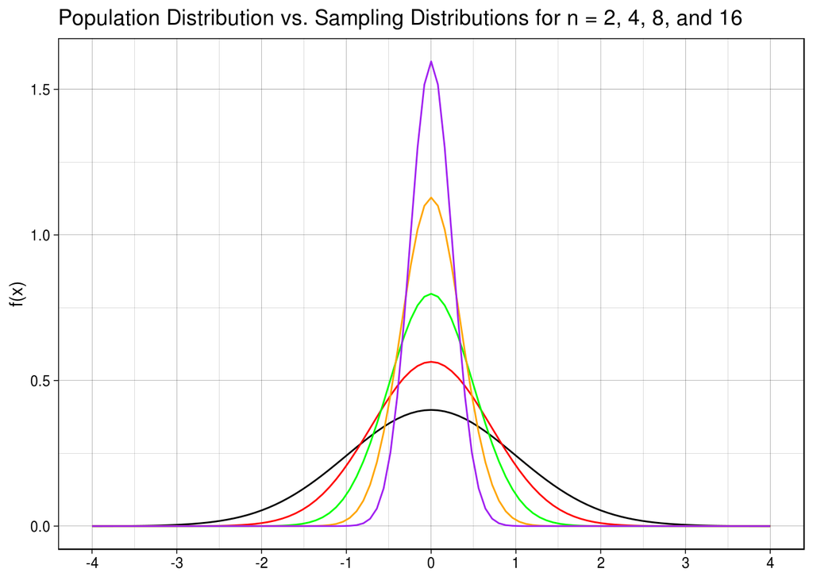

```r
mu    <- 0  # enter a value for the mean
sigma <- 1  # enter a value for the SD

ggplot(NULL, aes((mu - 4 * sigma):(mu + 4 * sigma))) +
  stat_function(fun = dnorm, args = list(mu, sigma)) +                           # population curve
  stat_function(fun = dnorm, args = list(mu, sigma/sqrt(2)), col = "red") +      # x-bar when n = 2
  stat_function(fun = dnorm, args = list(mu, sigma/sqrt(4)), col = "green") +    # x-bar when n = 4
  stat_function(fun = dnorm, args = list(mu, sigma/sqrt(8)), col = "orange") +   # x-bar when n = 8
  stat_function(fun = dnorm, args = list(mu, sigma/sqrt(16)), col = "purple") +  # x-bar when n = 8
  scale_x_continuous(breaks = seq(mu - (4 * sigma),  mu + (4 * sigma), sigma)) +
  labs(title = "Population Distribution vs. Sampling Distributions for n = 2, 4, 8, and 16",
       x = NULL,
       y = "f(x)") +
  theme_linedraw()
```

```r
tibble(n = c(1, 2, 4, 8, 16),
       SD = sigma/sqrt(n))
```

```
# A tibble: 5 x 2
      n    SD
  <dbl> <dbl>
1     1 1
2     2 0.707
3     4 0.5
4     8 0.354
5    16 0.25
```

#### Standardizing the Sampling Distribution

Prior to the advent of technology like `R` that can directly calculate probabilities, we needed to standardize scores in order to look up probabilities on a standard normal reference table. Standardized scores are also widely used in traditional statistical inference procedures, so it is important to understand the concept. Here we show it using simulation with randomly generated values from a normal distribution. You can experiment with different values for the population parameters and sample size. Pay attention to the scales on the x-axes of the four plots and how they change (or do not change) and you change the sample size.

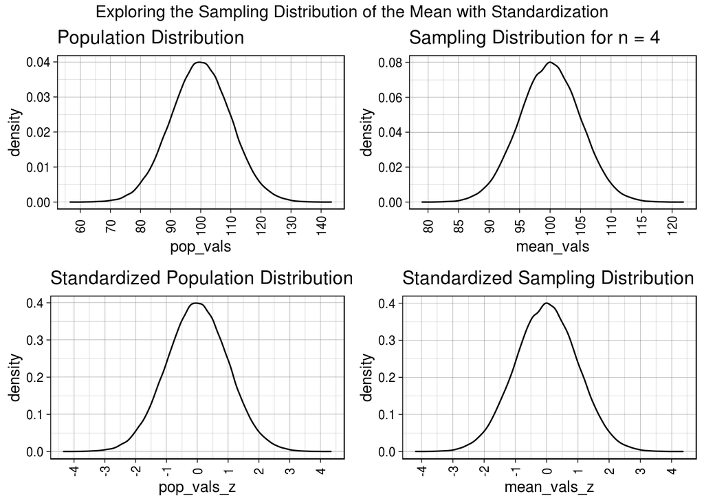

```r
mu         <- 100  # enter a value for the mean
sigma      <- 10   # enter a value for the SD
n          <- 4    # enter a value for the sample size (1 = population)
sigma_xbar <- sigma/sqrt(n)

pop_vals   <- rnorm(10^5, mu, sigma)   # 10^5 individual values from the population

pop_vals_z <- (pop_vals - mu) / sigma  # standardized population values (z-scores)

mean_vals <- numeric(10^5)  # 10^5 means from random samples of the chosen size n
for (i in 1:10^5) {
  mean_vals[i] <- mean(rnorm(n, mu, sigma))
}

mean_vals_z <- (mean_vals - mu) / (sigma_xbar)  #standardized means (zscores)

plotA <- ggplot(NULL, aes(x = pop_vals)) +
  geom_density() +
  scale_x_continuous(breaks = seq(mu - (6 * sigma),  mu + (6 * sigma), sigma)) +
  labs(title = "Population Distribution") +
  theme_linedraw() +
  theme(axis.text.x = element_text(angle = 90, vjust = .5))

plotB <- ggplot(NULL, aes(x = pop_vals_z)) +
  geom_density() +
  scale_x_continuous(breaks = seq(-6, 6, 1)) +
  labs(title = "Standardized Population Distribution") +
  theme_linedraw() +
  theme(axis.text.x = element_text(angle = 90, vjust = .5))

plotC <- ggplot(NULL, aes(x = mean_vals)) +
  geom_density() +
  scale_x_continuous(breaks = seq(mu - (6 * sigma_xbar),  mu + (6 * sigma_xbar), sigma_xbar)) +
  labs(title = paste("Sampling Distribution for n =", n)) +
  theme_linedraw() +
  theme(axis.text.x = element_text(angle = 90, vjust = .5))

plotD <- ggplot(NULL, aes(x = mean_vals_z)) +
  geom_density() +
  scale_x_continuous(breaks = seq(-6, 6, 1)) +
  labs(title = "Standardized Sampling Distribution") +
  theme_linedraw() +
  theme(axis.text.x = element_text(angle = 90, vjust = .5))

grid.arrange(plotA, plotC, plotB, plotD,
             top = "Exploring the Sampling Distribution of the Mean with Standardization")
```

#### Example: Protein in a Quarter Pound Patty

The amount of protein in a single patty

```r
mu    <- 21.4
sigma <- 1.9

x     <- 23.0
pnorm(x, mu, sigma, lower.tail = FALSE)
```

```
[1] 0.1998645
```

```r
z     <- (x - mu)/sigma
pnorm(z, lower.tail = FALSE)  # default settings are mu = 0 and sigma = 1
```

```
[1] 0.1998645
```

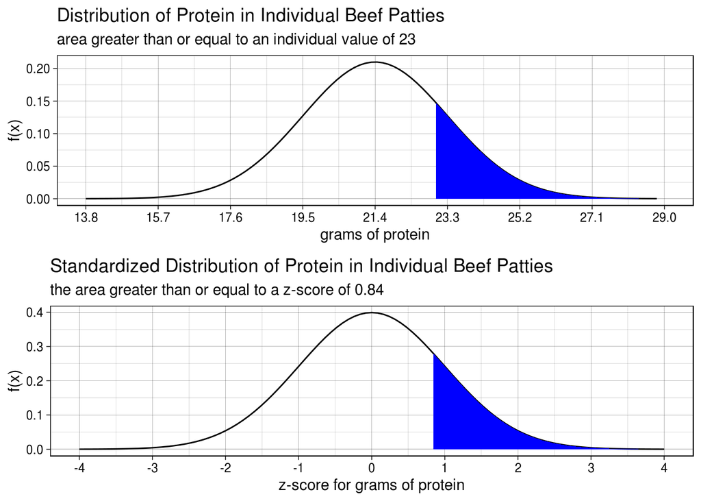

```r
plotX <- ggplot(NULL, aes((mu - 4 * sigma):(mu + 4 * sigma))) +
  stat_function(fun = dnorm, args = list(mu, sigma)) +
  geom_area(stat = "function",
            fun = dnorm,
            args = list(mu, sigma),
            fill = "blue",
            xlim = c(x, mu + 4 * sigma)) +  # shades from x to the upper limit
  scale_x_continuous(breaks = seq(mu - (4 * sigma),  mu + (4 * sigma), sigma)) +
  labs(title = "Distribution of Protein in Individual Beef Patties",
       subtitle = paste("area greater than or equal to an individual value of", x),
       x = "grams of protein",
       y = "f(x)") +
  theme_linedraw()

plotZ <- ggplot(NULL, aes(-4:4)) +
  stat_function(fun = dnorm) +
  geom_area(stat = "function",
            fun = dnorm,
            fill = "blue",
            xlim = c(z, 4)) +
  scale_x_continuous(breaks = seq(-4,  4, 1)) +
  labs(title = "Standardized Distribution of Protein in Individual Beef Patties",
       subtitle = paste("the area greater than or equal to a z-score of", round(z, 2)),
       x = "z-score for grams of protein",
       y = "f(x)") +
  theme_linedraw()

grid.arrange(plotX, plotZ)
```

The average amount of protein $n$ patties

```r
mu         <- 21.4
sigma      <- 1.9
n          <- 7

sigma_xbar <- sigma/sqrt(n)

x_bar      <- 20.0
round(pnorm(x_bar, mu, sigma_xbar, lower.tail = FALSE), digits = 3) # more than
```

```
[1] 0.974
```

```r
round(pnorm(x_bar, mu, sigma_xbar), digits = 3)
```

```
[1] 0.026
```

```r
round((z_xbar     <- (x_bar - mu)/sigma_xbar), digits = 3)
```

```
[1] -1.95
```

```r
pnorm(z_xbar, lower.tail = FALSE)# default settings are mu = 0 and sigma = 1
```

```
[1] 0.9743822
```

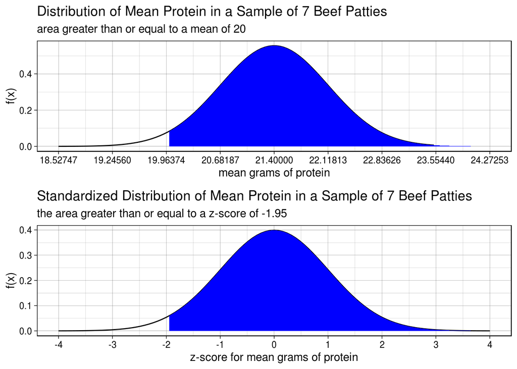

```r
plotXbar <- ggplot(NULL, aes((mu - 4 * sigma_xbar):(mu + 4 * sigma_xbar))) +
  stat_function(fun = dnorm, args = list(mu, sigma_xbar)) +
  geom_area(stat = "function",
            fun = dnorm,
            args = list(mu, sigma_xbar),
            fill = "blue",
            xlim = c(x_bar, mu + 4 * sigma_xbar)) +
  scale_x_continuous(breaks = seq(mu - (4 * sigma_xbar),  mu + (4 * sigma_xbar), sigma_xbar)) +
  labs(title = paste("Distribution of Mean Protein in a Sample of", n, "Beef Patties"),
       subtitle = paste("area greater than or equal to a mean of", x_bar),
       x = "mean grams of protein",
       y = "f(x)") +
  theme_linedraw()

plotZxbar <- ggplot(NULL, aes(-4:4)) +
  stat_function(fun = dnorm) +
  geom_area(stat = "function",
            fun = dnorm,
            fill = "blue",
            xlim = c(z_xbar, 4)) +
  scale_x_continuous(breaks = seq(-4,  4, 1)) +
  labs(title = paste("Standardized Distribution of Mean Protein in a Sample of", n, "Beef Patties"),
       subtitle = paste("the area greater than or equal to a z-score of", round(z_xbar, 2)),
       x = "z-score for mean grams of protein",
       y = "f(x)") +
  theme_linedraw()

grid.arrange(plotXbar, plotZxbar)
```